# Bayesian modeling and prediction for movies

## Setup

### Load packages

```r
library(ggplot2)
library(dplyr)
library(tidyr)
library(statsr)
library(BAS)
```

### Load data

```r
setwd('/Users/linghao/dukeR/linear-regression-model/final')
load('movies.Rdata')
```

## Part 1: Data

### Overview of Data

The dataset `movies` is comprised of 651 randomly sampled movies produced and released before 2016, including information from both **Rotten Tomatoes** and **IMDb**.

### Scope of Inference

The dataset should be considered as the result of an **retrospective observational study** that uses a **random sampling** approach to obtain a representative sample from U.S. movies. Since random sampling method is applied in data collection, **the results should be generalizable** to the target population.

Note that observational studies only reveal associations. In data analysis, **association does not imply causation**. Causation can only be inferred from a randomized experiment. **This study does not meet the requirements of such an experiment.**

## Part 2: Data manipulation

Five new variables are created according to the instruction.

```r
movies <- mutate(movies, feature_film=as.factor(ifelse(title_type=='Feature Film', 'yes', 'no')))
movies <- mutate(movies, drama=as.factor(ifelse(genre=='Drama', 'yes', 'no')))
movies <- mutate(movies, mpaa_rating_R=as.factor(ifelse(mpaa_rating=='R', 'yes', 'no')))
movies <- mutate(movies, oscar_season=as.factor(ifelse(thtr_rel_month %in% c(10, 11, 12), 'yes', 'no')))
movies <- mutate(movies, summer_season=as.factor(ifelse(thtr_rel_month %in% c(5, 6, 7, 8), 'yes', 'no')))
```

## Part 3: Exploratory data analysis

Since the response variable here is always `audience_score`, we expect to see the same scale for y-axis. Therefore we can use `gather` function from `tidyr` package to **stack all 5 newly created variable into a single column**.

```r
movies_gathered <- gather(movies, 'variable', 'flag', 33:37)
```

Then we create a side-by-side boxplot.

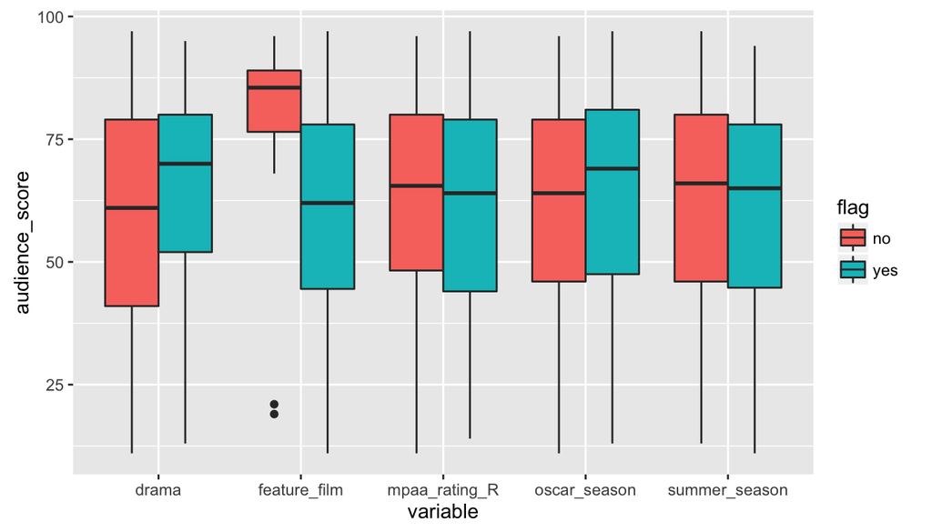

```r
ggplot(movies_gathered, aes(x=variable, y=audience_score, fill=flag)) + geom_boxplot()
```

Also the numerical summary statistics.

```r
movies_gathered %>%
  group_by(variable, flag) %>%
  summarise(mean=mean(audience_score), median=median(audience_score), min=min(audience_score), max=max(audience_score), IQR=IQR(audience_score))
```

```
## Source: local data frame [10 x 7]
## Groups: variable [?]
##
##         variable  flag     mean median   min   max   IQR
##            <chr> <chr>    <dbl>  <dbl> <dbl> <dbl> <dbl>
## 1          drama    no 59.73121   61.0    11    97 38.00
## 2          drama   yes 65.34754   70.0    13    95 28.00
## 3   feature_film    no 81.05000   85.5    19    96 12.50
## 4   feature_film   yes 60.46531   62.0    11    97 33.50
## 5  mpaa_rating_R    no 62.68944   65.5    11    96 31.75
## 6  mpaa_rating_R   yes 62.04255   64.0    14    97 35.00
## 7   oscar_season    no 61.81304   64.0    11    96 33.00
## 8   oscar_season   yes 63.68586   69.0    13    97 33.50
## 9  summer_season    no 62.62302   66.0    13    97 34.00
## 10 summer_season   yes 61.80769   65.0    11    94 33.25
```

From the plot and the summary, it’s clear that **drama movies tend to have higher scores than other genres**. And that **feature films have much lower scores than non-feature films**. Other variables, however, do not seem to have any significant impact on scores.

## Part 4: Modeling

Let’s now perform Bayesian model averaing.

```r
model <- bas.lm(data=na.omit(movies), audience_score ~ feature_film + drama + runtime + mpaa_rating_R
               + thtr_rel_year + oscar_season + summer_season + imdb_rating + imdb_num_votes
               + critics_score + best_pic_nom + best_pic_win + best_actor_win + best_actress_win
               + best_dir_win + top200_box, prior = 'BIC', modelprior = uniform())
```

Let’s print out marginal posterior inclusion probability for each variable.

```r
model
```

[output not shown]

We can see that `imdb_rating` has a posterior inclusion probability of 1.00, which sounds quite logical in the context of movie industry. Besides `critics_score` and `runtime` also have pretty high probabilities.

Then let’s see the summary of models.

```r
summary(model)
```

```
##      Intercept feature_filmyes dramayes runtime mpaa_rating_Ryes
## [1,]         1               0        0       1                0
## [2,]         1               0        0       0                0
## [3,]         1               0        0       0                0
## [4,]         1               0        0       1                1
## [5,]         1               0        0       1                0
##      thtr_rel_year oscar_seasonyes summer_seasonyes imdb_rating
## [1,]             0               0                0           1
## [2,]             0               0                0           1
## [3,]             0               0                0           1
## [4,]             0               0                0           1
## [5,]             0               0                0           1
##      imdb_num_votes critics_score best_pic_nomyes best_pic_winyes
## [1,]              0             1               0               0
## [2,]              0             1               0               0
## [3,]              0             1               0               0
## [4,]              0             1               0               0
## [5,]              0             1               1               0
##      best_actor_winyes best_actress_winyes best_dir_winyes top200_boxyes
## [1,]                 0                   0               0             0
## [2,]                 0                   0               0             0
## [3,]                 0                   1               0             0
## [4,]                 0                   0               0             0
## [5,]                 0                   0               0             0
##             BF PostProbs     R2 dim   logmarg
## [1,] 1.0000000    0.1558 0.7483   4 -3434.752
## [2,] 0.8715404    0.1358 0.7455   3 -3434.889
## [3,] 0.2048238    0.0319 0.7470   4 -3436.338
## [4,] 0.2039916    0.0318 0.7496   5 -3436.342
## [5,] 0.1851908    0.0289 0.7495   5 -3436.438
```

We see that the best model is consisted of `Intercept`, `runtime`, `imdb_rating` and `critics_score`, which is consistent with the findings above.

Let’s now fit the best model and interpret it’s coefficients.

```r
final_model <- lm(data=na.omit(movies), audience_score ~ imdb_rating + critics_score + runtime)
final_model
```

```
##
## Call:
## lm(formula = audience_score ~ imdb_rating + critics_score + runtime,
##     data = na.omit(movies))
##
## Coefficients:
##   (Intercept)    imdb_rating  critics_score        runtime
##     -32.90825       14.95043        0.07531       -0.05791
```

We see that `imdb_rating` has a coefficient of `14.95`, meaning that for each additional score on `imdb_rating`, we expect `audience_score` to be higher by `14.95`. Since IMDB score is given on a scale of 0 to 10 and `audience_score` is given on a scale of 0 to 100, as well as taking `Intercept = -32.90` into account, it makes perfect sense.

Similarly, for each additional score on `critics_score`, we expect `audience_score` to be higher by `0.075`. Obviously this is not as impacting as `imdb_rating`.

Finally, for each additional minute of a movie’s running time, we expect to see a decrese of `0.058` in `audience_score`. This means that in general people don’t like lengthy movies. Note that the IQR for `runtime` is `23.8` minutes, which means that for most movies the different in `runtime` only contributes to no more than `2` points in `audience_score`.

## Part 5: Prediction

We now use our final model to predict the audience score of *X-MEN: Apocalypse*. Information about this film can be found at http://www.imdb.com/title/tt3385516/ and https://www.rottentomatoes.com/m/x_men_apocalypse

```r
new_movie <- data.frame(runtime=144, imdb_rating=7.3, critics_score=48)
predict(final_model, new_movie)
```

```
##        1
## 71.50632
```

The model predicted a `71.5` audience score, which is suprisingly close to the true value `71`.

## Part 6: Conclusion

The fact that `imdb_rating` has the highest posterior probability, and that two of our five newly created variables which seem to have predictive power are not included in the best model, is quite disappointing. Because **IMDB ratings are somewhat in sync with audience scores and thus are very useless as leading predictors**. The same applies to `critics_score`.

Nevertheless, we do have some insights that might turn out to be useful. Drame films are more popular; feature/non-feature films have an outstanding split with regard to their audience scores; Longer movies generally bore the audience, etc.

The current approach does not account for another layer of “prior” knowledge inside our brain – the availability of different variables also impact their predictive power.